# HW2

```python
import numpy as np
import matplotlib.pyplot as plt
import pandas as pd
from sklearn.preprocessing import normalize,scale,MinMaxScaler
import os
from scipy.linalg import svd
from PIL import Image
from skimage.transform import resize
```

```python
# THE FUNCTION TO READ THE IMAGES:
def read_pgm(pgmf):
    pgmf = open(pgmf, 'rb')
    """Return a raster of integers from a PGM as a list of lists."""
    assert pgmf.readline() == b'P5\n'
    (width, height) = [int(i) for i in pgmf.readline().split()]
    depth = int(pgmf.readline())
    assert depth <= 255

    raster = []
    for y in range(height):
        row = []
        for y in range(width):
            row.append(ord(pgmf.read(1)))
        raster.append(row)
    return raster
```

```python
# READ ALL THE IMAGES:
images = []
for root, dirs, files in os.walk("/home/cdsw/data/CroppedYale/"):
    for file in files:
        if file.endswith('.pgm'):
            im = resize(
                np.array(read_pgm(os.path.join(root, file))), (40, 40))
            images.append(im)
print(len(images))
```

```
2414
```

```python
# OUR DATA MATRIX WHERE EACH IMAGE IS A COLUMN
data = np.array(images).reshape(len(images),1600).transpose()
data.shape
```

```
(1600, 2414)
```

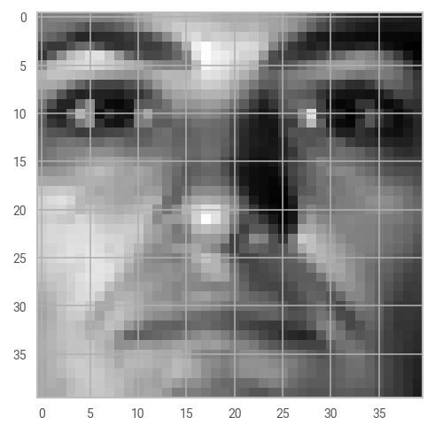

```python
# EXAMPLE IMAGE
plt.imshow(data[:,-1].reshape(40,40),cmap=plt.get_cmap('gray'))
```

## 1 . Do an SVD analysis of the images (where each image is reshaped into a column vector and each column is a new image).

### Please see the code below:

```python
u,s,v = svd(data,full_matrices=True)
print(data.shape)
print(u.shape)
print(np.diag(s).shape)
print(v.shape)
```

```
(1600, 2414)
(1600, 1600)
(1600, 1600)
(2414, 2414)
```

## 2. What is the interpretation of the U, Σ and V matrices? (Plot the first few reshaped columns of U)?

## Asnwer:

### In a typical SVD samples are in rows and features are in columns. Here we are instucted to put the image vectors as columns in to the data matrix which we means that they are our features. Each pixel in the data matrix has a different value for each image. When we perform SVD, we aim to reduce this representation such that each pixel can be represented by fewer number of summary images. So U is pixels to summary images matrix. Σ is the strength of each summary image and V is images to summary images matrix that tells us the contribution of each image to the each summary image. Here are the first few reshaped columns of U:

### Please see the code below:

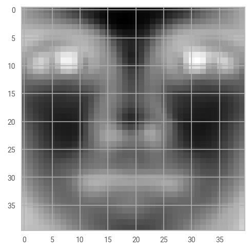

```python
plt.imshow(u[:,0].reshape(40,40),cmap=plt.get_cmap('gray'))
```

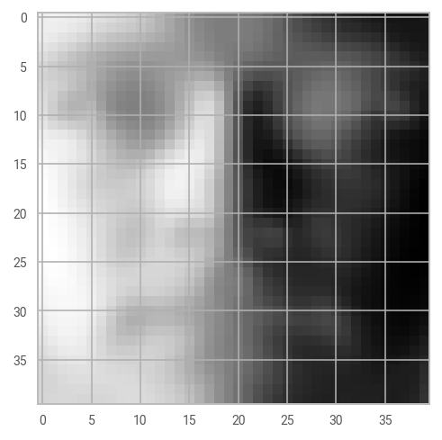

```python
plt.imshow(u[:,1].reshape(40,40),cmap=plt.get_cmap('gray'))
```

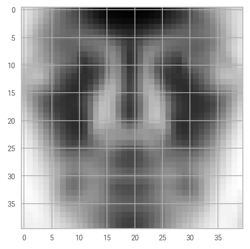

```python
plt.imshow(u[:,2].reshape(40,40),cmap=plt.get_cmap('gray'))
```

## 3. What does the singular value spectrum look like and how many modes are necessary for good image reconstructions using the PCA basis? (i.e. what is the rank r of the face space?)

## Answer:

### Singular value spectrum decays very rapidly. As shown below about 80% of the variation in the images can be preserved by the first 200 components. Although this is subjective and depends on the application, the first 200 components will be enough.

### Please see the code below:

[figure not shown]

```python
# PLOTTING THE SINGULAR VALUES
fig, (ax1, ax2) = plt.subplots(1, 2)
ax1.plot(s)
ax1.set(xlabel='Num of components',ylabel='Singular Values')
ax2.plot(s[:100])
ax2.set(xlabel='Num of components',ylabel='Singular Values')
```

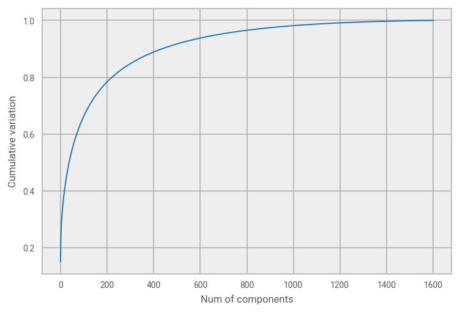

```python
fig, ax1 = plt.subplots(1)
ax1.plot(np.cumsum(s/s.sum()))
ax1.set(xlabel='Num of components',ylabel='Cumulative variation')
```

## 4. compare the difference between the cropped (and aligned) versus uncropped images in terms of singular value decay and reconstruction capabilities.

## Answer:

### I see the following differences:

### 1) In terms of SVD spectrum, more components are needed to fully cover the variation in pixels. The reason could be that the images are less standardized. (For examples 200/1600=0.125 or 12.5% of the components cover 80% of the variation in cropped images vs. 50/165=0.30 or 30% of the components are needed to cover 80% of the variation in uncropped images).

### 2) Average images look very different. The average images in cropped images focus on details on each image like eyes, mouth etc. The average imagse in uncropped images focus on the fact that there is an head in each image. I think the difference is due to the fact that the most of the variation in cropped images is within the face itself and the everything else is standard. Compare that with uncropped images, there is quite a bit of variation in terms of the position of the head within the image.

### Please see the code below:

```python
# READ ALL THE IMAGES:
uncropped_images = []
for root, dirs, files in os.walk("/home/cdsw/data/yalefaces/"):
    for file in files:
        im = resize(
            np.asarray(Image.open(os.path.join(root, file))), (80, 80))
        uncropped_images.append(im)
print(len(uncropped_images))
```

```
165
```

```python
# OUR DATA MATRIX WHERE EACH IMAGE IS A COLUMN
uncropped_data = np.array(uncropped_images).reshape(len(uncropped_images),6400).transpose()
uncropped_data.shape
```

```
(6400, 165)
```

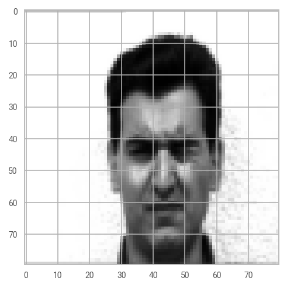

```python
# EXAMPLE IMAGE
plt.imshow(uncropped_data[:,-1].reshape(80,80),cmap=plt.get_cmap('gray'))
```

```python
# SVD DECOMPOSITION OF THE IMAGES
u1,s1,v1 = svd(uncropped_data,full_matrices=True)
print(uncropped_data.shape)
print(u1.shape)
print(np.diag(s1).shape)
print(v1.shape)
```

```
(6400, 165)
(6400, 6400)
(165, 165)
(165, 165)
```

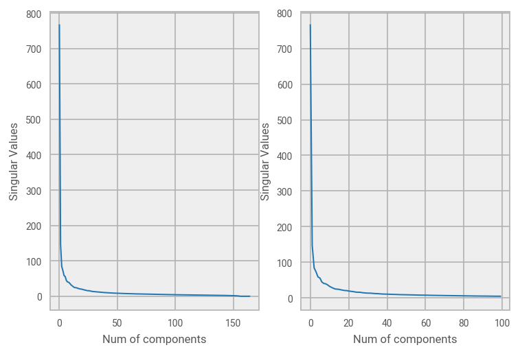

```python
# PLOTTING THE SINGULAR VALUES
fig, (ax1, ax2) = plt.subplots(1, 2)
ax1.plot(s1)
ax1.set(xlabel='Num of components',ylabel='Singular Values')
ax2.plot(s1[:100])
ax2.set(xlabel='Num of components',ylabel='Singular Values')
```

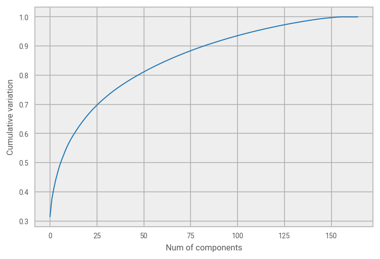

```python
fig, ax1 = plt.subplots(1)
ax1.plot(np.cumsum(s1/s1.sum()))
ax1.set(xlabel='Num of components',ylabel='Cumulative variation')
```

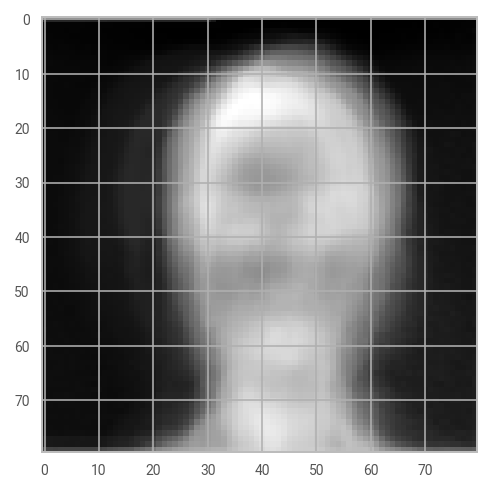

```python
plt.imshow(u1[:,0].reshape(80,80),cmap=plt.get_cmap('gray'))
```